# Data Overview Report

Aitor Vázquez Veloso

2024-09-22

## Data Overview

This report provides an overview of the dataset.

### Column: IFN_PLOT_ID

Type: character

Number of missing values: 0

[output not shown]

[output cut: 110 more lines]

### Column: INVENTORY_ID

Type: character

Number of missing values: 0

```
##
##  IFN2  IFN3  IFN4
## 93272 99047 57723
```

### Column: Province

Type: integer

Number of missing values: 7714

```
##    Min. 1st Qu.  Median    Mean 3rd Qu.    Max.    NA's
##    1.00   13.00   24.00   24.57   36.00   50.00    7714
```

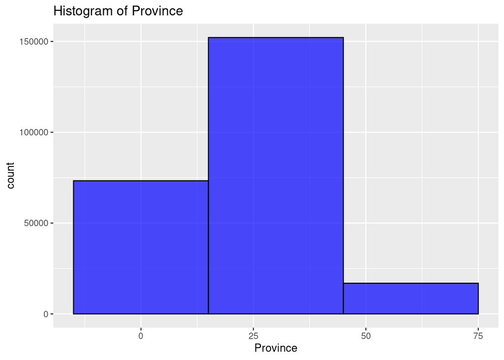

### Column: Province_name

Type: character

Number of missing values: 4645

```
##
##                  Álava               Albacete               Alicante                Almería               Asturias                  Ávila                Badajoz               Baleares
##                   3650                   5132                   2312                   2388                   6849                   4559                   5873                   3447
##              Barcelona                Bizkaia                 Burgos                Cáceres                  Cádiz              Cantabria              Castellón            Ciudad Real
##                   8997                   3254                   7712                   7973                   2529                   5587                   4076                   4384
##                Córdoba                 Coruña                 Cuenca               Gipuzkoa                 Girona                Granada            Guadalajara                 Huelva
##                   2689                   9525                   8398                   3046                   7478                   3741                   6306                   5140
##                 Huesca                   Jaén                   León                 Lleida                   Lugo                 Madrid                 Málaga                 Murcia
##                   7020                   4060                   5207                   8609                   7688                   5803                   2939                   5099
##                Navarra                Ourense               Palencia                 Palmas             Pontevedra                  Rioja              Salamanca Santa Cruz de Tenerife
##                   7986                   5196                   2398                   1754                   4023                   4277                   5190                   5065
##                Segovia                Sevilla                  Soria              Tarragona                 Teruel                 Toledo               Valencia             Valladolid
##                   2637                   7365                   3942                   6458                   3609                   4377                   2642                   2931
##                 Zamora
##                   4077
```

### Column: N_plot

Type: integer

Number of missing values: 0

```
##    Min. 1st Qu.  Median    Mean 3rd Qu.    Max.
##       1     530    1089    1279    1850    9999
```

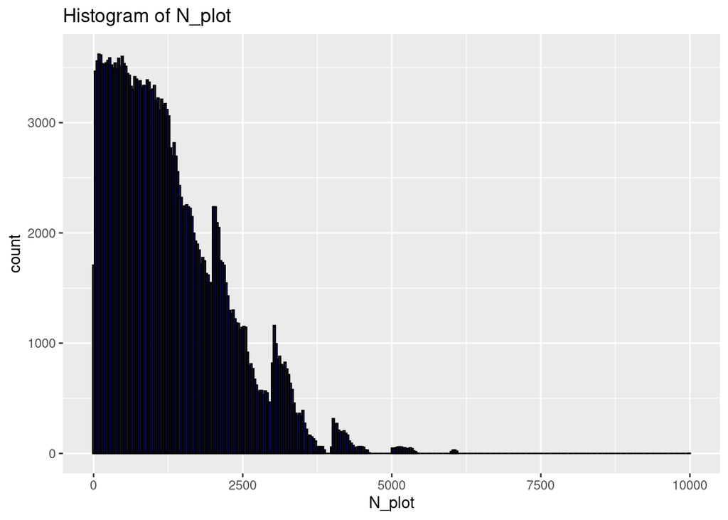

### Column: Class

Type: character

Number of missing values: 93272

```
##
##      1      2      3      4      A      N      R
##    249    118     14      6 129926  25866    591
```

### Column: Subclass

Type: character

Number of missing values: 93272

```
##
##     1    1R     2    2C    2E    2R     3    3C    3E     4    4C     5    6C     N     R
## 97374    26   130   273   273    23    15  5653  5652 15870  3157    11  2447 25748   118
```

### Column: PLOT_ID

Type: character

Number of missing values: 0

[output not shown]

[output cut: 110 more lines]

### Column: PLOT_ID_short

Type: character

Number of missing values: 0

[output not shown]

[output cut: 54 more lines]

### Column: Slope_max

Type: double

Number of missing values: 10009

```
##     Min.  1st Qu.   Median     Mean  3rd Qu.     Max.     NA's
##    0.000    2.750    6.000    6.421    9.500 1225.000    10009
```

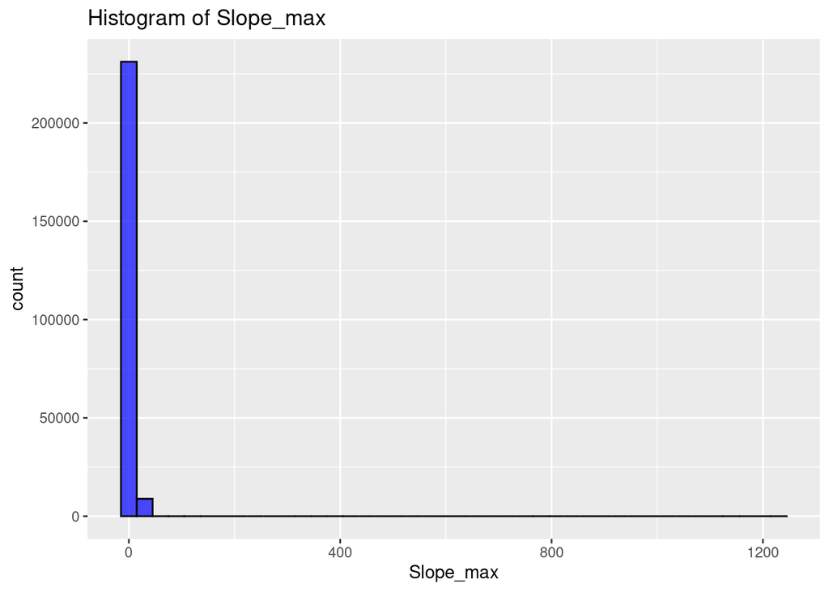

### Column: N

Type: double

Number of missing values: 52776

```
##    Min. 1st Qu.  Median    Mean 3rd Qu.    Max.    NA's
##     0.0   127.3   360.8   527.9   746.3  8994.0   52776
```

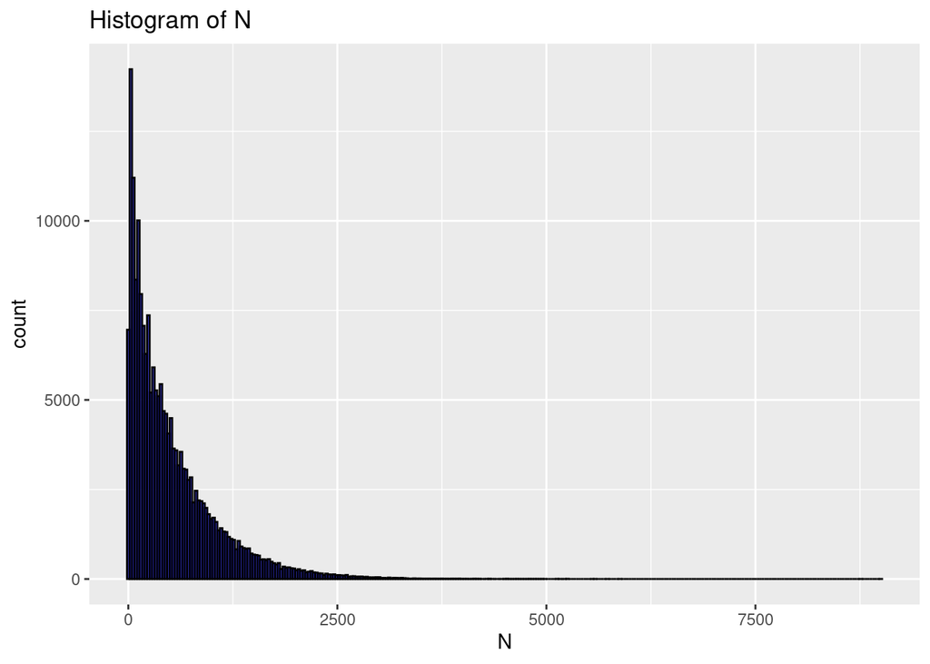

### Column: N_0_75

Type: double

Number of missing values: 52776

```
##    Min. 1st Qu.  Median    Mean 3rd Qu.    Max.    NA's
##    0.00    0.00    0.00    2.94    0.00  636.62   52776
```

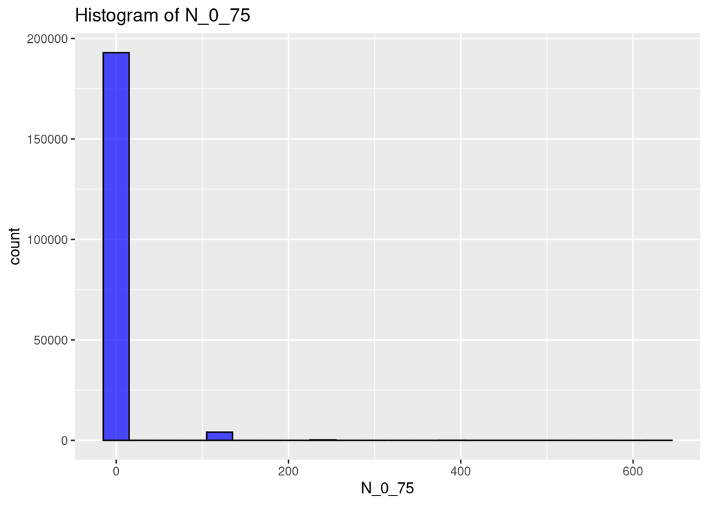

### Column: N_75_125

Type: double

Number of missing values: 52776

```
##    Min. 1st Qu.  Median    Mean 3rd Qu.    Max.    NA's
##     0.0     0.0   127.3   237.5   286.5  6270.7   52776
```

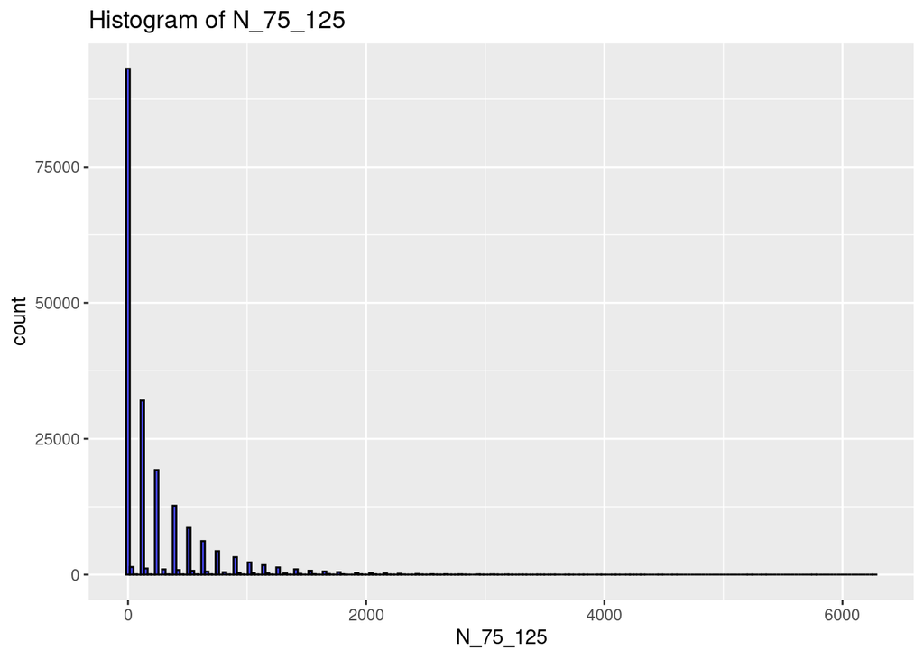

### Column: N_125_175

Type: double

Number of missing values: 52776

```
##    Min. 1st Qu.  Median    Mean 3rd Qu.    Max.    NA's
##    0.00    0.00   63.66  118.73  159.15 1909.86   52776
```

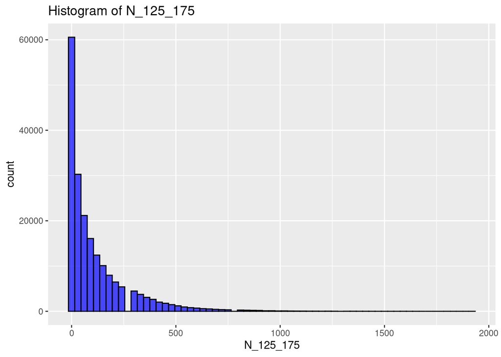

### Column: N_175_225

Type: double

Number of missing values: 52776

```
##    Min. 1st Qu.  Median    Mean 3rd Qu.    Max.    NA's
##    0.00    0.00   31.83   70.63   95.49 1177.75   52776
```

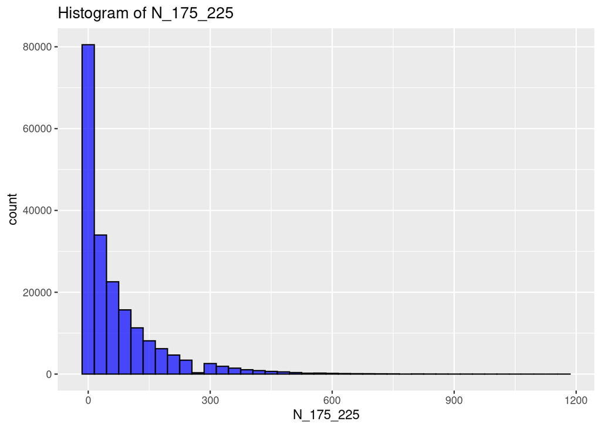

### Column: N_225_275

Type: double

Number of missing values: 52776

```
##    Min. 1st Qu.  Median    Mean 3rd Qu.    Max.    NA's
##    0.00    0.00   14.15   40.61   56.59  664.91   52776
```

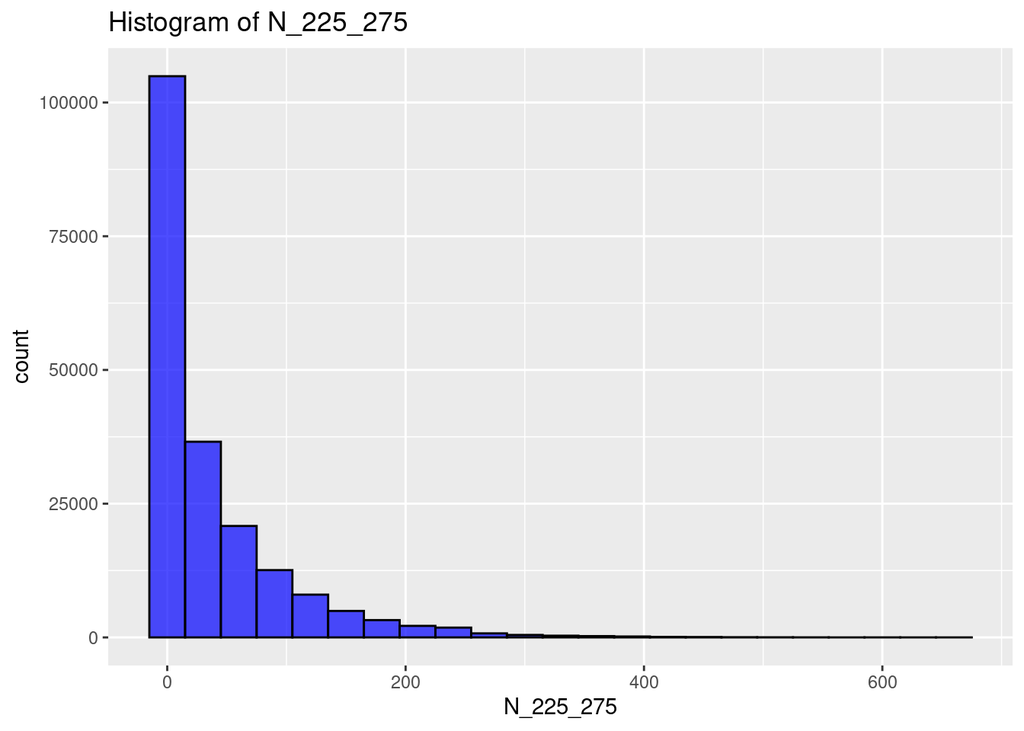

### Column: N_275_325

Type: double

Number of missing values: 52776

```
##    Min. 1st Qu.  Median    Mean 3rd Qu.    Max.    NA's
##    0.00    0.00   14.15   24.58   28.29  481.00   52776
```

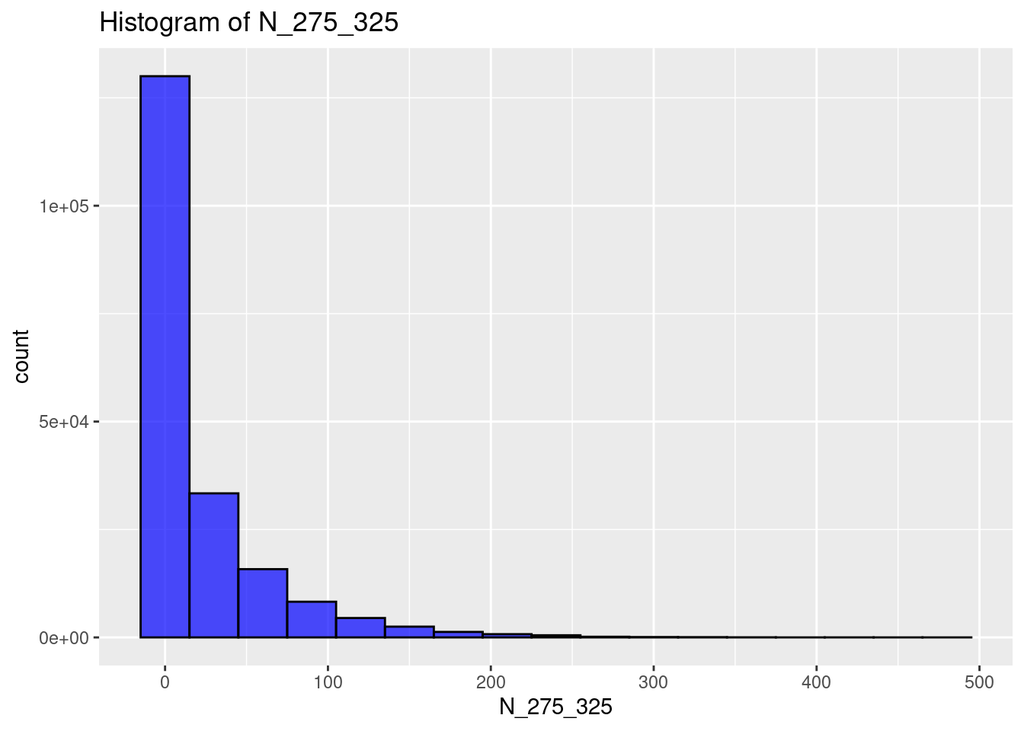

### Column: N_325_375

Type: double

Number of missing values: 52776

```
##    Min. 1st Qu.  Median    Mean 3rd Qu.    Max.    NA's
##    0.00    0.00    0.00   14.46   14.15  396.12   52776
```

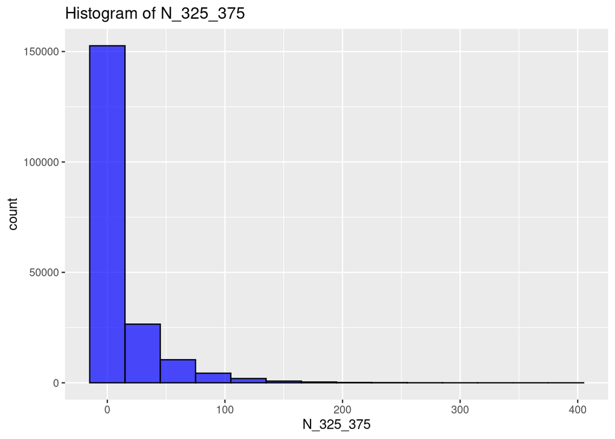

### Column: N_375_425

Type: double

Number of missing values: 52776

```
##    Min. 1st Qu.  Median    Mean 3rd Qu.    Max.    NA's
##    0.00    0.00    0.00    8.24   14.15  268.80   52776
```

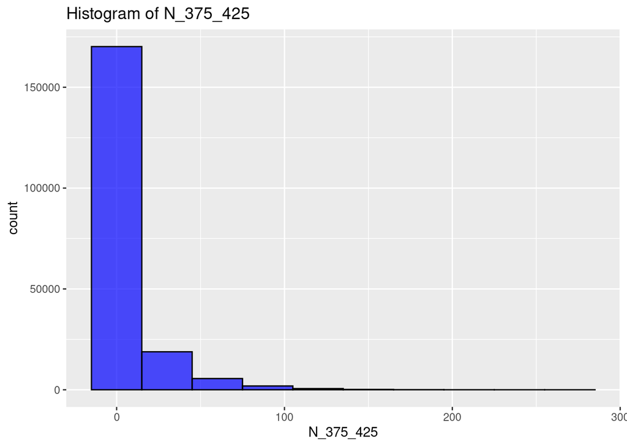

### Column: N_425_

Type: double

Number of missing values: 52776

```
##    Min. 1st Qu.  Median    Mean 3rd Qu.    Max.    NA's
##    0.00    0.00    0.00   10.24   10.19  305.58   52776
```

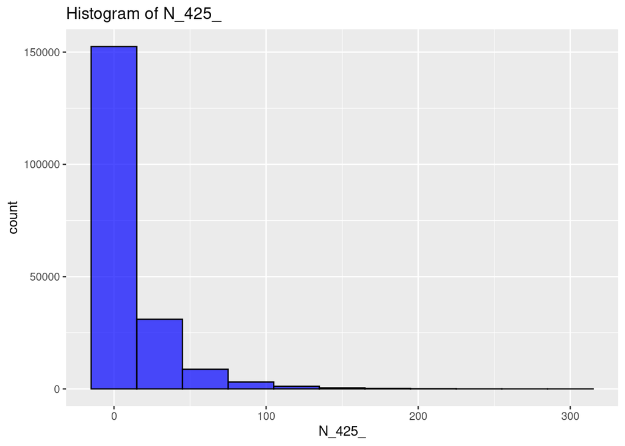

### Column: dbh_min

Type: double

Number of missing values: 52776

```
##    Min. 1st Qu.  Median    Mean 3rd Qu.    Max.    NA's
##    0.00    8.15   11.05   14.18   15.85  307.10   52776
```

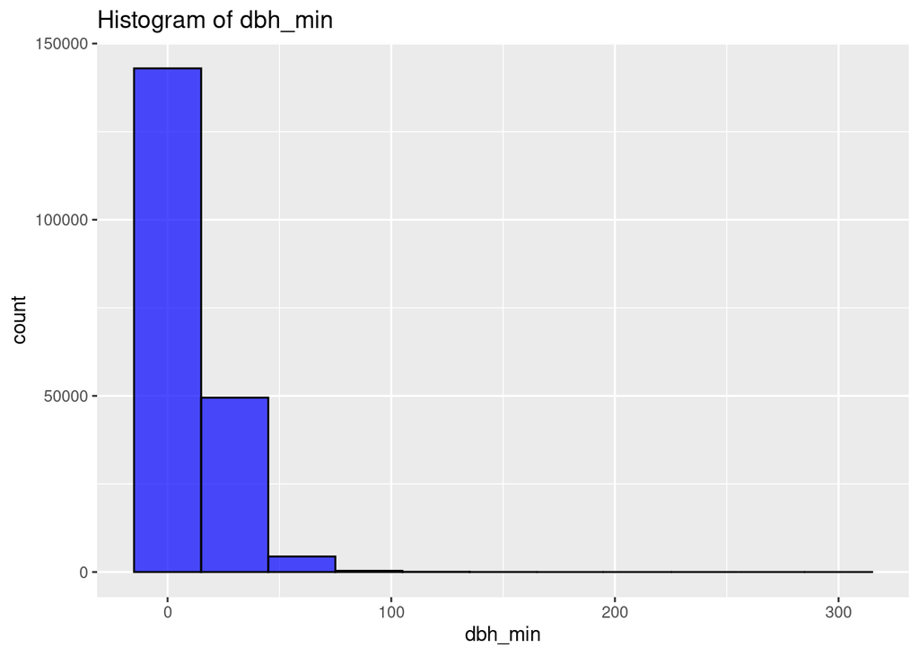

### Column: dbh_max

Type: double

Number of missing values: 52776

```
##    Min. 1st Qu.  Median    Mean 3rd Qu.    Max.    NA's
##    0.00   25.25   36.00   40.40   51.45  307.10   52776
```

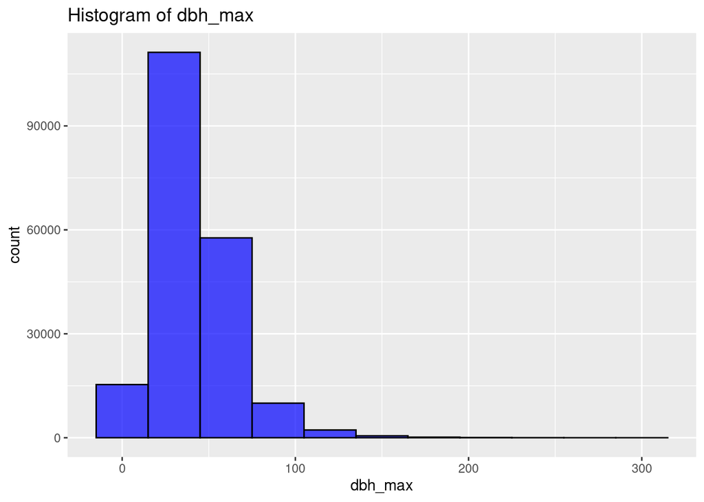

### Column: dbh_mean

Type: double

Number of missing values: 53300

```
##    Min. 1st Qu.  Median    Mean 3rd Qu.    Max.    NA's
##    7.50   13.58   18.24   21.60   25.90  307.10   53300
```

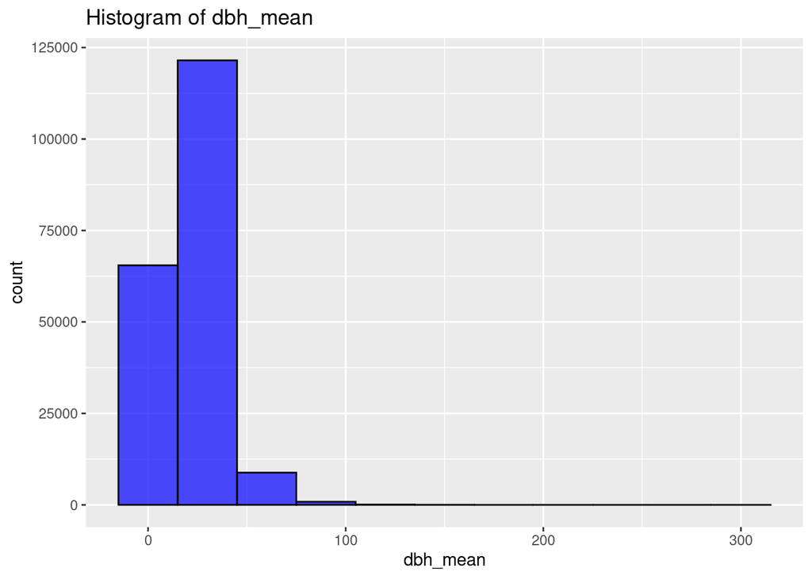

### Column: dg

Type: double

Number of missing values: 53300

```
##    Min. 1st Qu.  Median    Mean 3rd Qu.    Max.    NA's
##    7.50   14.56   19.67   22.84   27.53  307.10   53300
```

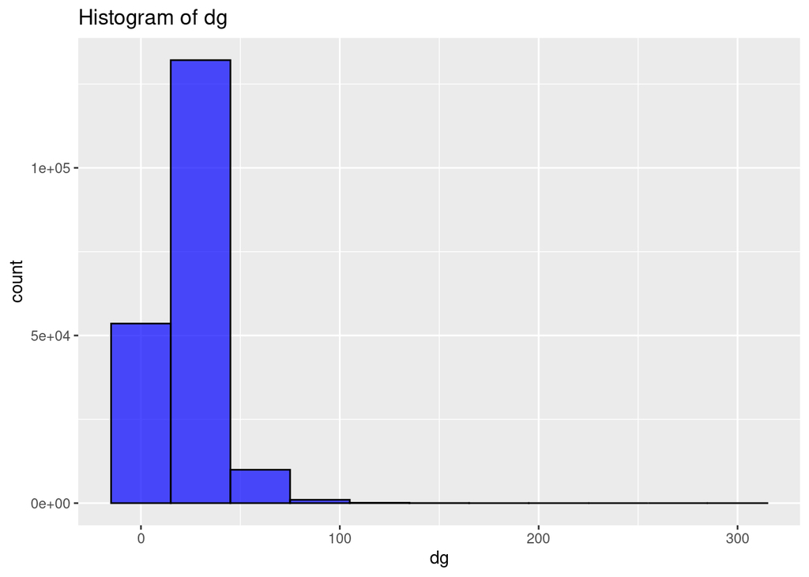

### Column: G

Type: double

Number of missing values: 52776

```
##    Min. 1st Qu.  Median    Mean 3rd Qu.    Max.    NA's
##    0.00    4.69   11.08   14.63   21.46  128.50   52776
```

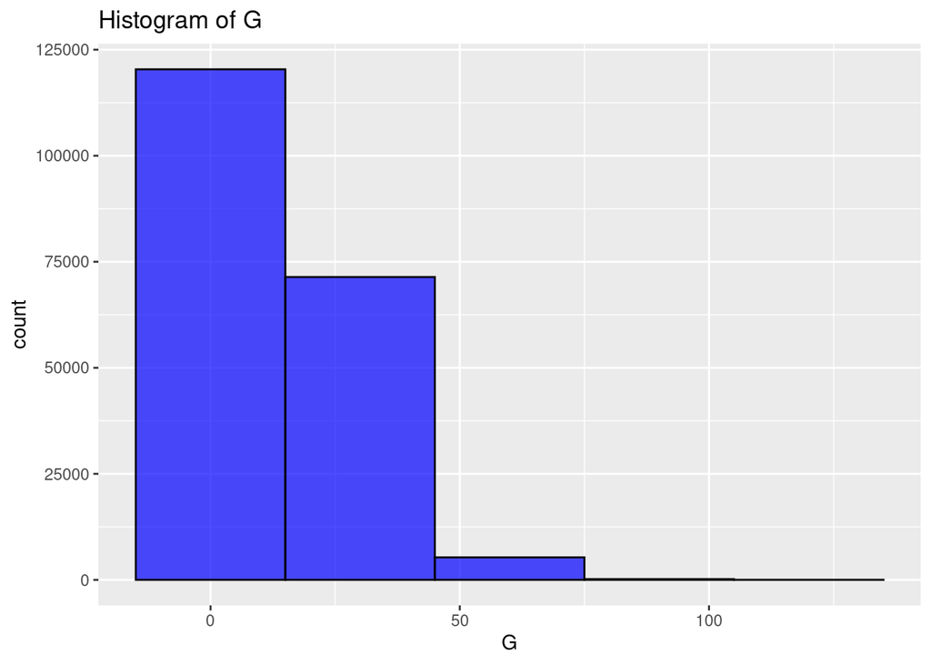

### Column: g_min

Type: double

Number of missing values: 52776

```
##     Min.  1st Qu.   Median     Mean  3rd Qu.     Max.     NA's
##     0.00    52.17    95.90   246.56   197.31 74071.22    52776
```

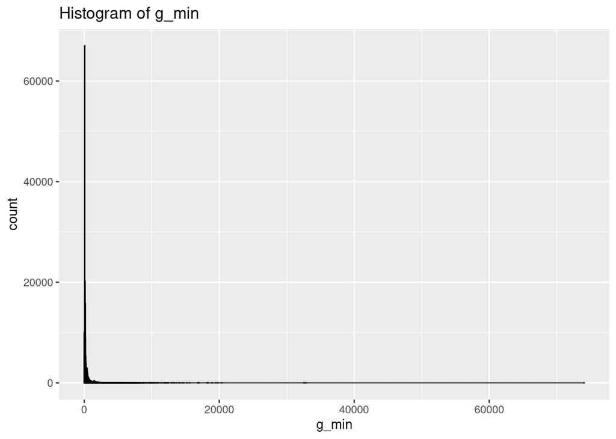

### Column: g_max

Type: double

Number of missing values: 52776

```
##    Min. 1st Qu.  Median    Mean 3rd Qu.    Max.    NA's
##     0.0   500.7  1017.9  1664.8  2079.0 74071.2   52776
```

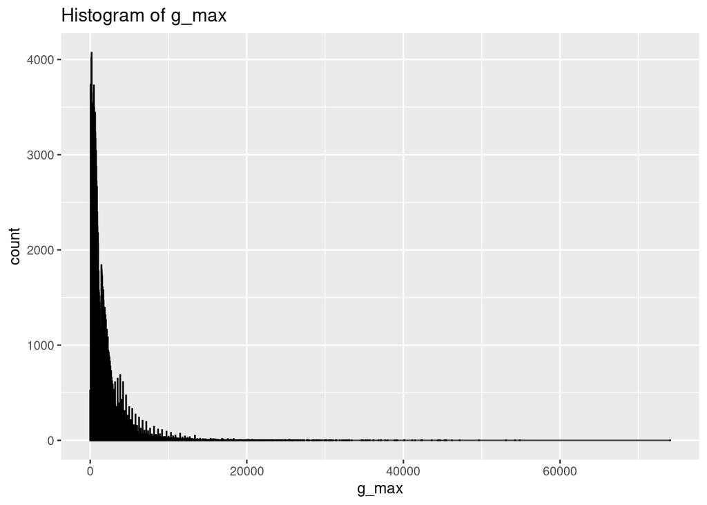

### Column: g_mean

Type: double

Number of missing values: 53300

```
##     Min.  1st Qu.   Median     Mean  3rd Qu.     Max.     NA's
##    44.18   166.46   303.98   527.44   595.42 74071.22    53300
```

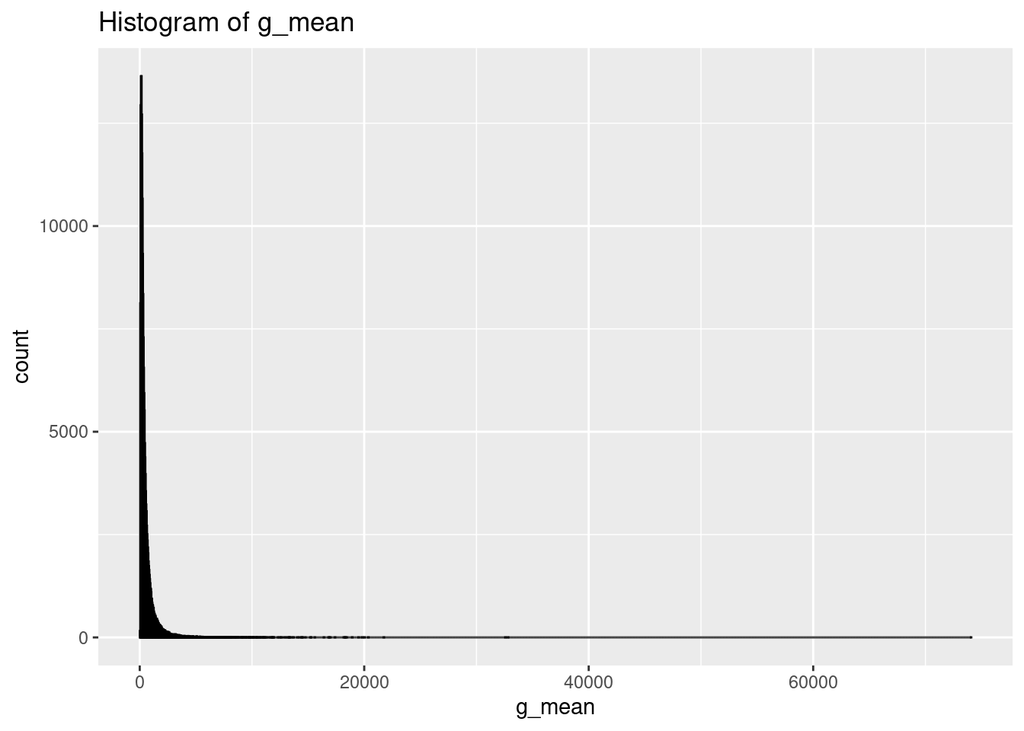

### Column: h_min

Type: double

Number of missing values: 53031

```
##    Min. 1st Qu.  Median    Mean 3rd Qu.    Max.    NA's
##    0.00    4.00    5.50    6.03    7.50   52.00   53031
```

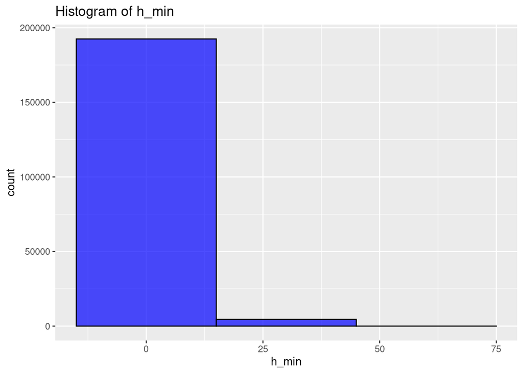

### Column: h_max

Type: double

Number of missing values: 53031

```
##    Min. 1st Qu.  Median    Mean 3rd Qu.    Max.    NA's
##    0.00    8.30   12.00   13.73   17.50   80.00   53031
```

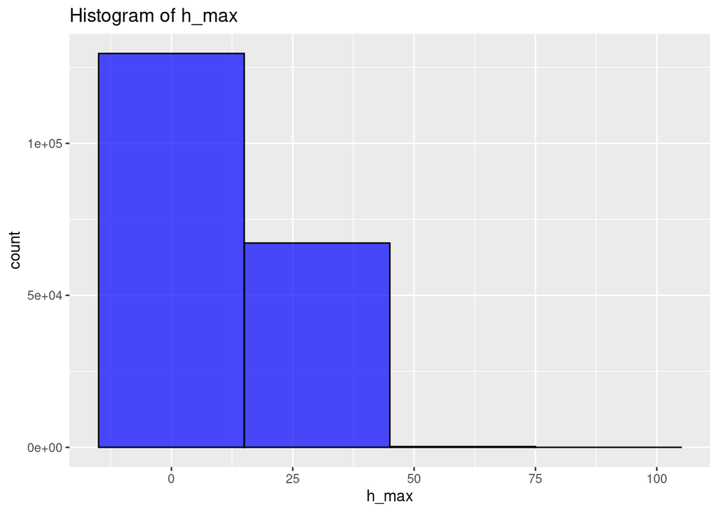

### Column: h_mean

Type: double

Number of missing values: 53300

```
##    Min. 1st Qu.  Median    Mean 3rd Qu.    Max.    NA's
##    0.00    5.98    8.13    9.19   11.31   52.00   53300
```

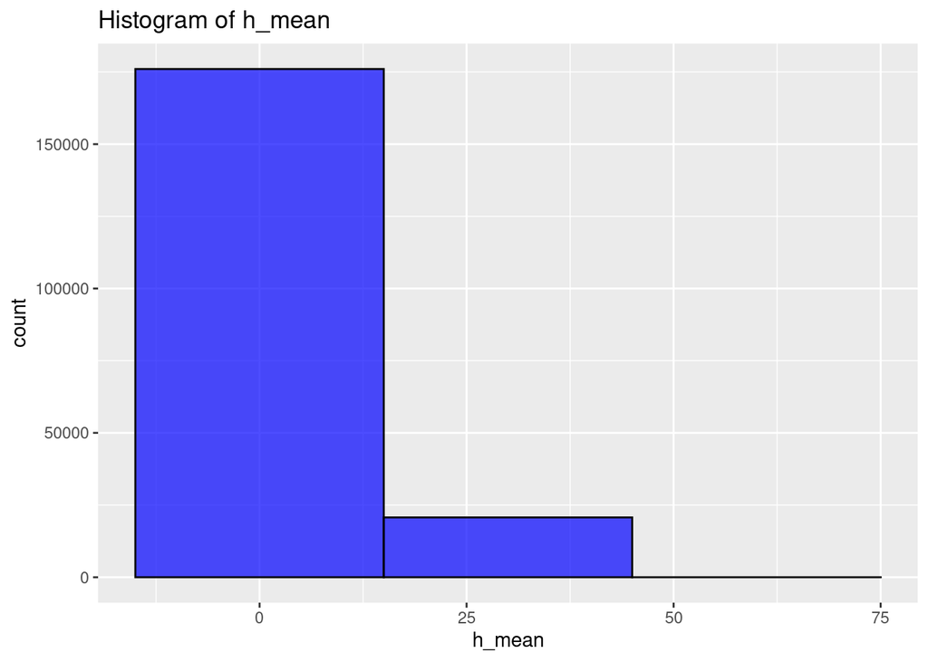

### Column: Ho

Type: double

Number of missing values: 53980

```
##    Min. 1st Qu.  Median    Mean 3rd Qu.    Max.    NA's
##    0.10    7.11   10.28   11.67   14.78   52.00   53980
```

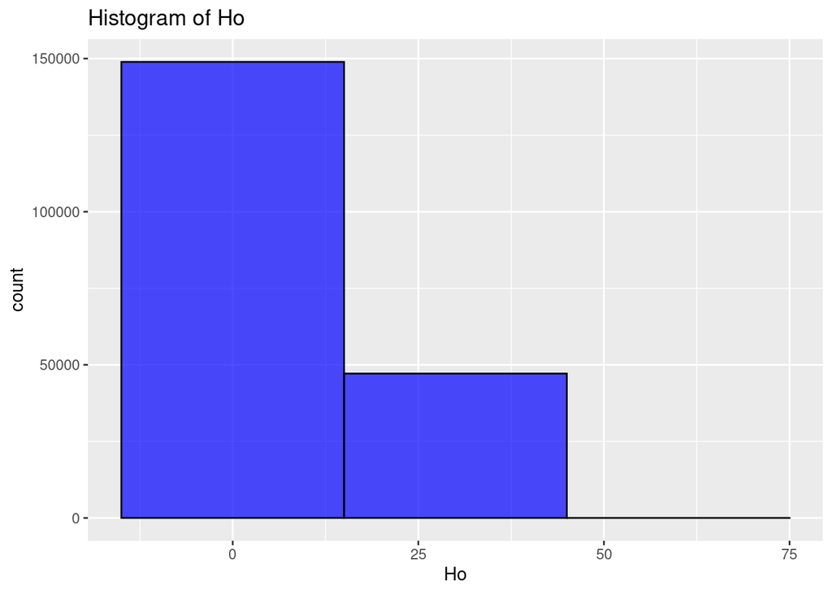

### Column: Do

Type: double

Number of missing values: 53300

```
##    Min. 1st Qu.  Median    Mean 3rd Qu.    Max.    NA's
##    7.50   19.97   27.13   28.75   35.58  307.10   53300
```

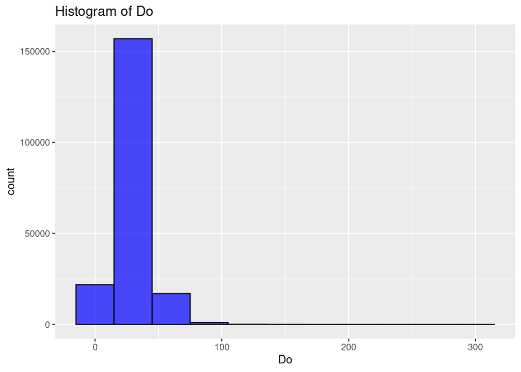

### Column: sp_1

Type: integer

Number of missing values: 53305

```
##    Min. 1st Qu.  Median    Mean 3rd Qu.    Max.    NA's
##     1.0    24.0    28.0    46.3    45.0   957.0   53305
```

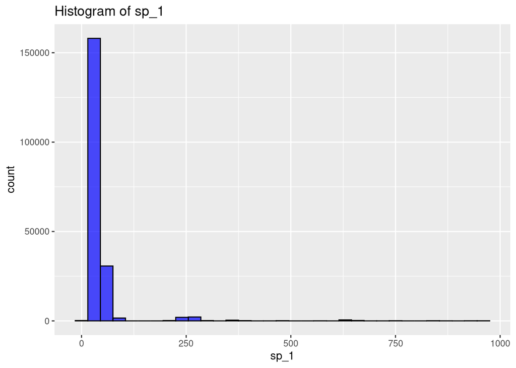

### Column: sp_2

Type: integer

Number of missing values: 169801

```
##    Min. 1st Qu.  Median    Mean 3rd Qu.    Max.    NA's
##    1.00   26.00   44.00   71.17   61.00  957.00  169801
```

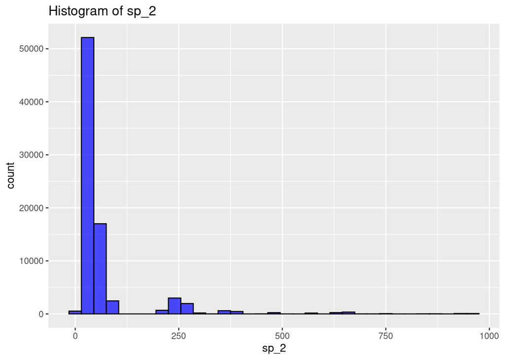

### Column: sp_3

Type: integer

Number of missing values: 219533

```
##    Min. 1st Qu.  Median    Mean 3rd Qu.    Max.    NA's
##     3.0    38.0    45.0    97.9    74.0   957.0  219533
```

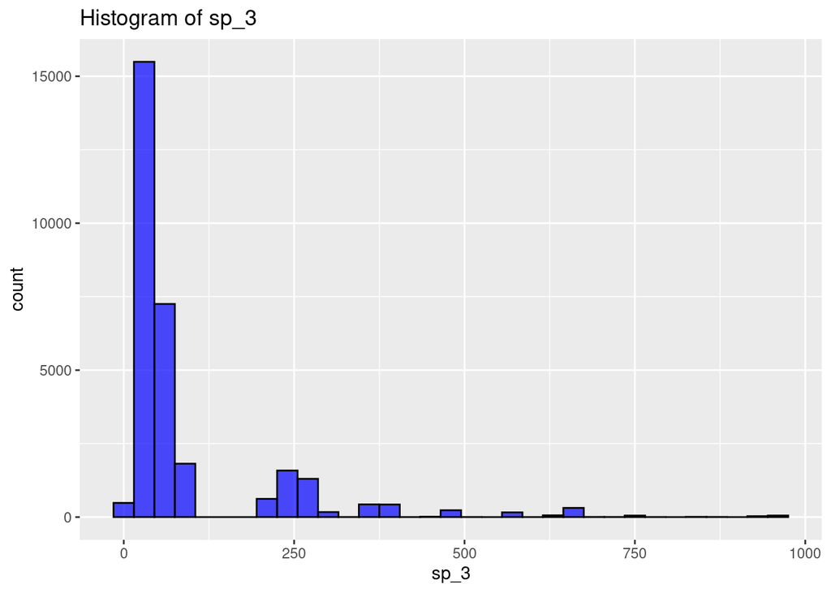

### Column: G_sp_1

Type: double

Number of missing values: 52776

```
##    Min. 1st Qu.  Median    Mean 3rd Qu.    Max.    NA's
##    0.00    4.09    9.27   12.76   18.13  128.50   52776
```

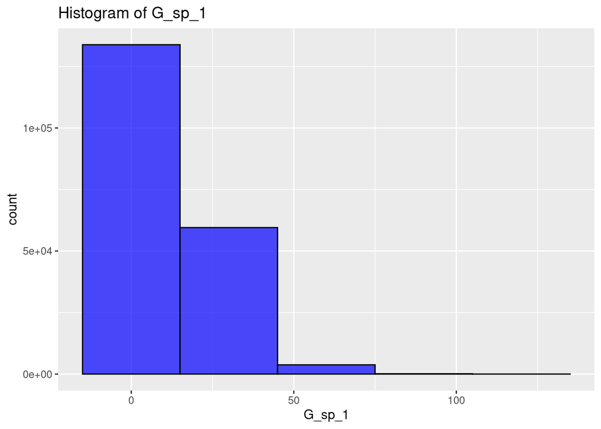

### Column: G_sp_2

Type: double

Number of missing values: 165161

```
##    Min. 1st Qu.  Median    Mean 3rd Qu.    Max.    NA's
##    0.00    0.97    2.15    3.37    4.59   36.06  165161
```

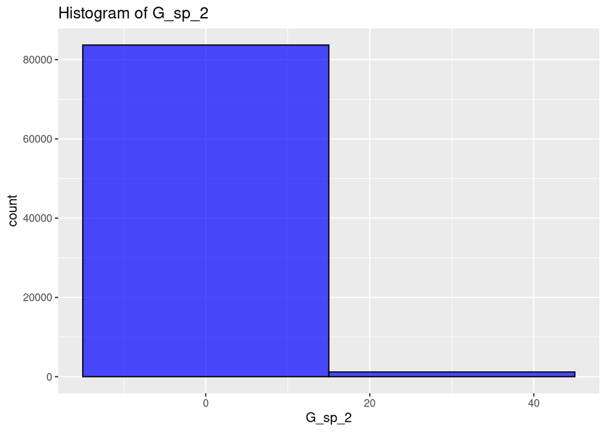

### Column: G_sp_3

Type: double

Number of missing values: 216737

```
##    Min. 1st Qu.  Median    Mean 3rd Qu.    Max.    NA's
##    0.00    0.68    1.21    1.77    2.31   19.67  216737
```

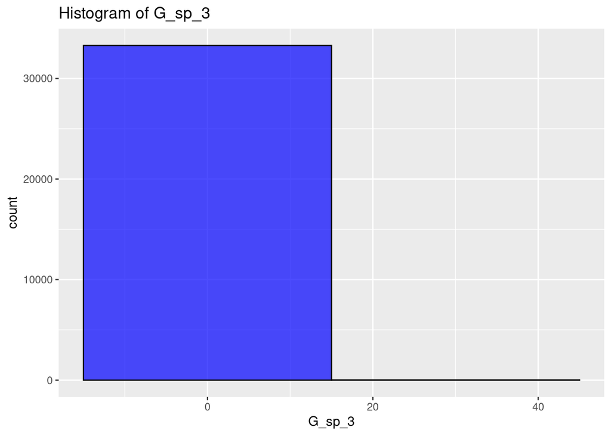

### Column: N_sp_1

Type: double

Number of missing values: 52776

```
##    Min. 1st Qu.  Median    Mean 3rd Qu.    Max.    NA's
##     0.0   105.2   282.9   441.8   605.8  8994.0   52776
```

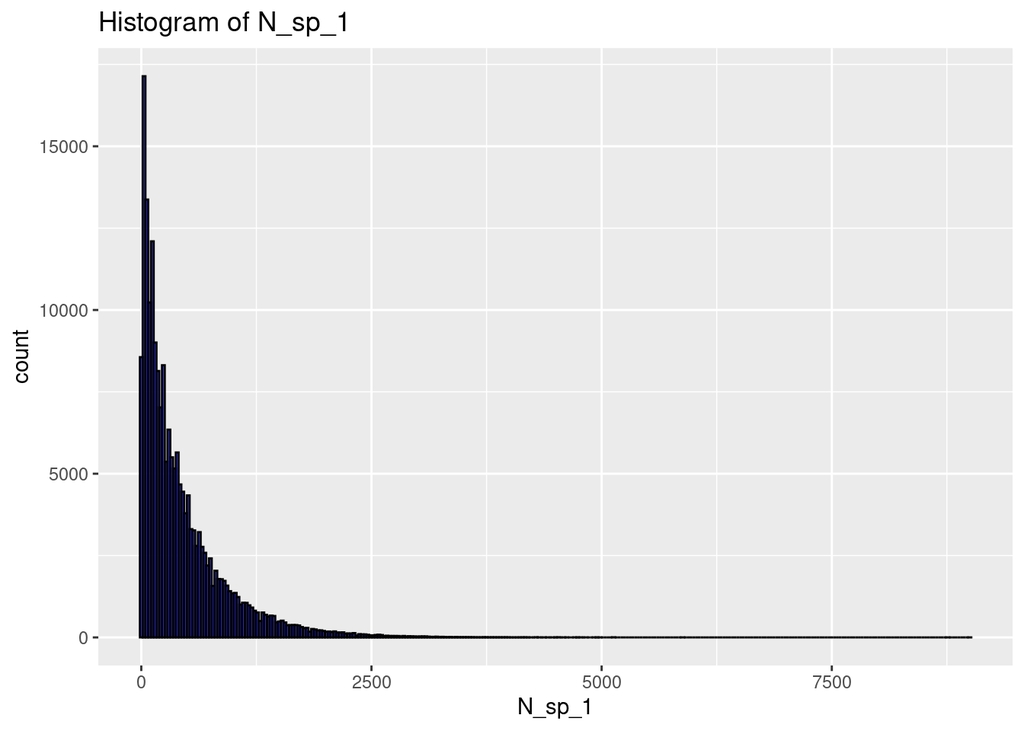

### Column: N_sp_2

Type: double

Number of missing values: 165161

```
##    Min. 1st Qu.  Median    Mean 3rd Qu.    Max.    NA's
##    0.00   28.29   74.27  150.67  190.99 2624.29  165161
```

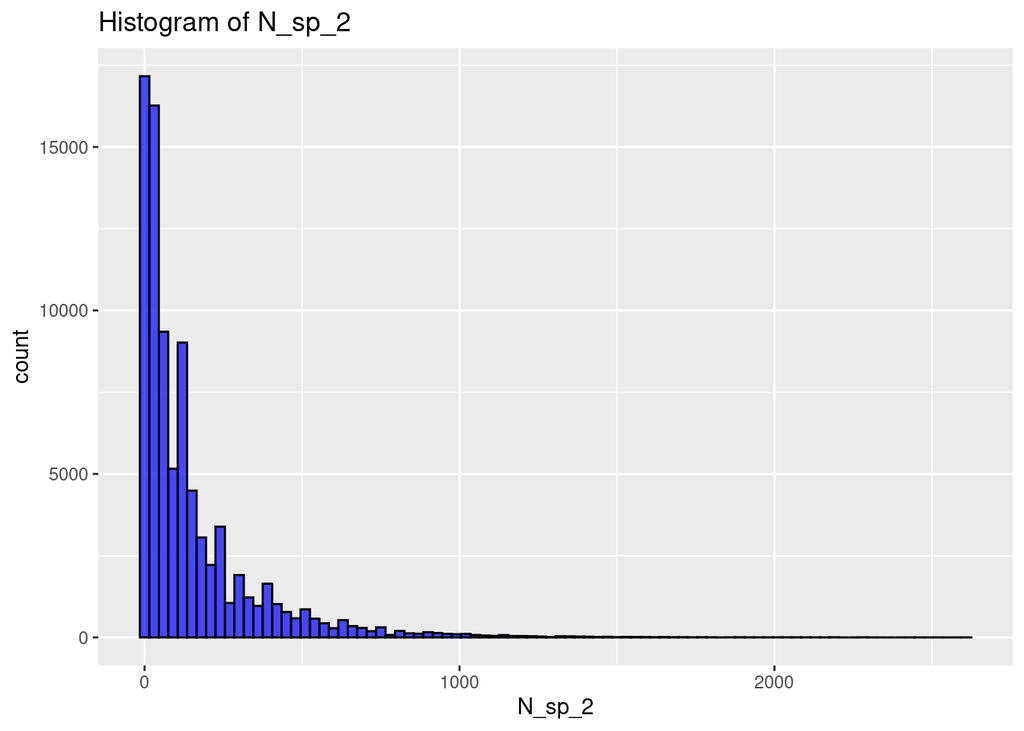

### Column: N_sp_3

Type: double

Number of missing values: 216737

```
##    Min. 1st Qu.  Median    Mean 3rd Qu.    Max.    NA's
##    0.00   14.15   31.83   89.67  127.32 1478.37  216737
```

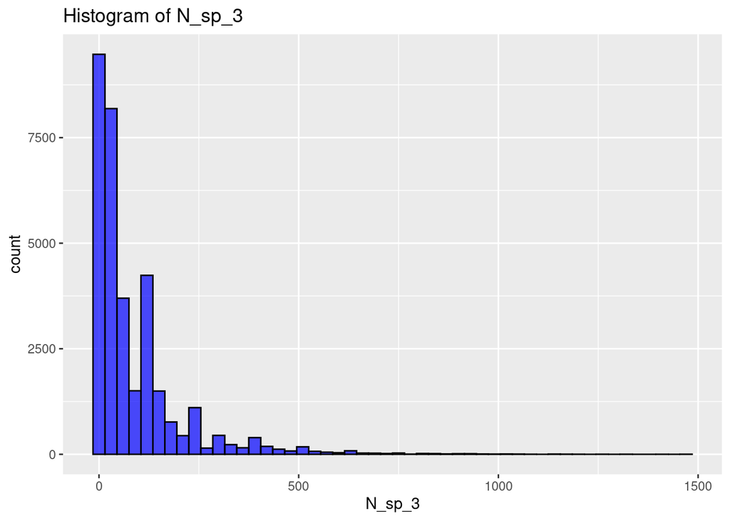

### Column: G_alive

Type: double

Number of missing values: 52776

```
##    Min. 1st Qu.  Median    Mean 3rd Qu.    Max.    NA's
##    0.00    4.59   10.86   14.30   21.05  126.31   52776
```

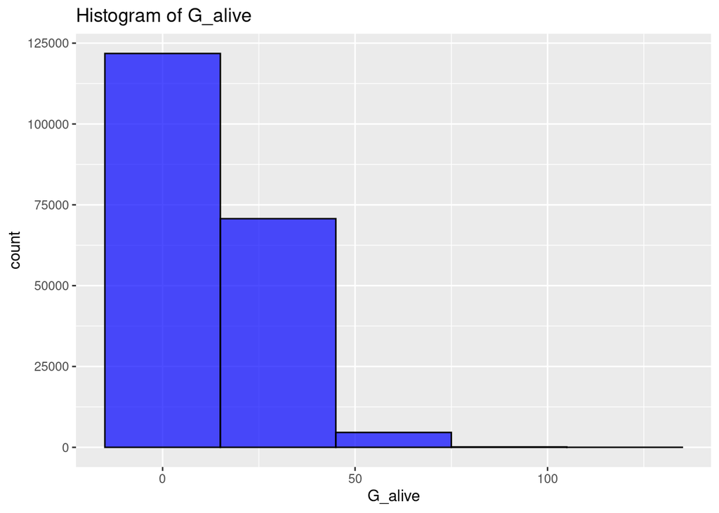

### Column: G_dead

Type: double

Number of missing values: 214333

```
##    Min. 1st Qu.  Median    Mean 3rd Qu.    Max.    NA's
##    0.00    0.50    1.02    1.80    2.12   49.04  214333
```

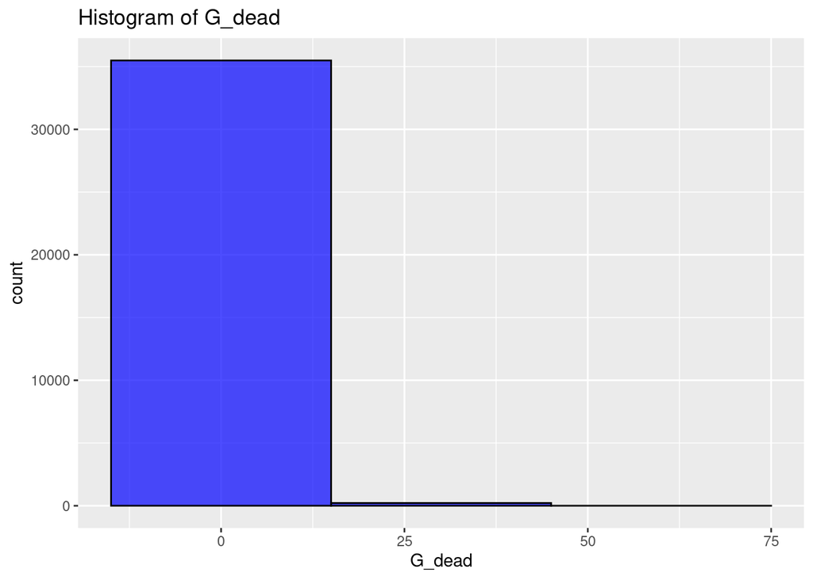

### Column: N_alive

Type: double

Number of missing values: 52776

```
##    Min. 1st Qu.  Median    Mean 3rd Qu.    Max.    NA's
##     0.0   127.3   350.1   512.7   724.2  8994.0   52776
```

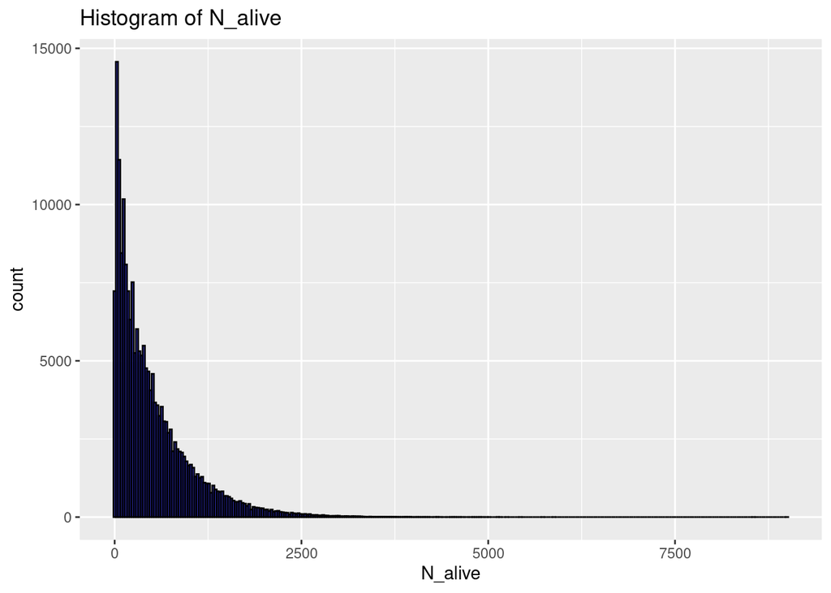

### Column: N_dead

Type: double

Number of missing values: 214333

```
##    Min. 1st Qu.  Median    Mean 3rd Qu.    Max.    NA's
##    0.00    5.09   31.83   84.09  127.32 3743.47  214333
```

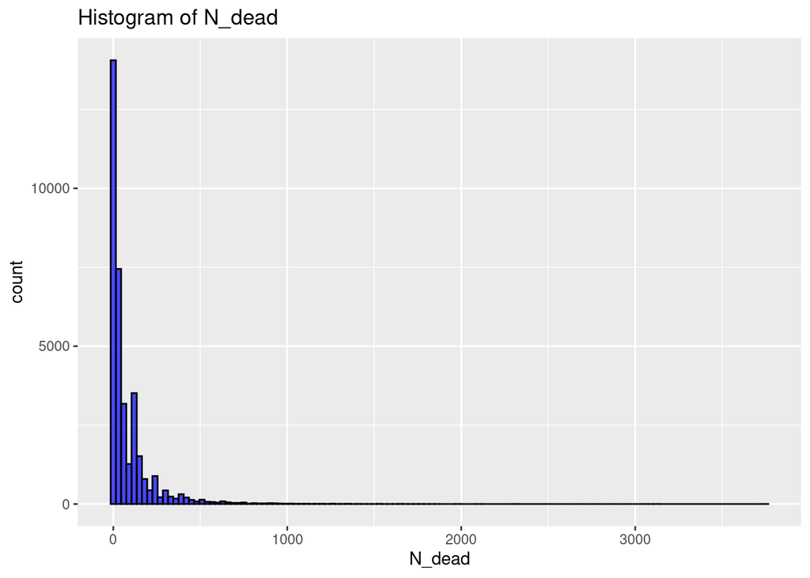

### Column: slenderness

Type: double

Number of missing values: 53300

```
##    Min. 1st Qu.  Median    Mean 3rd Qu.    Max.    NA's
##    0.00   34.07   44.59   47.13   57.21  183.22   53300
```

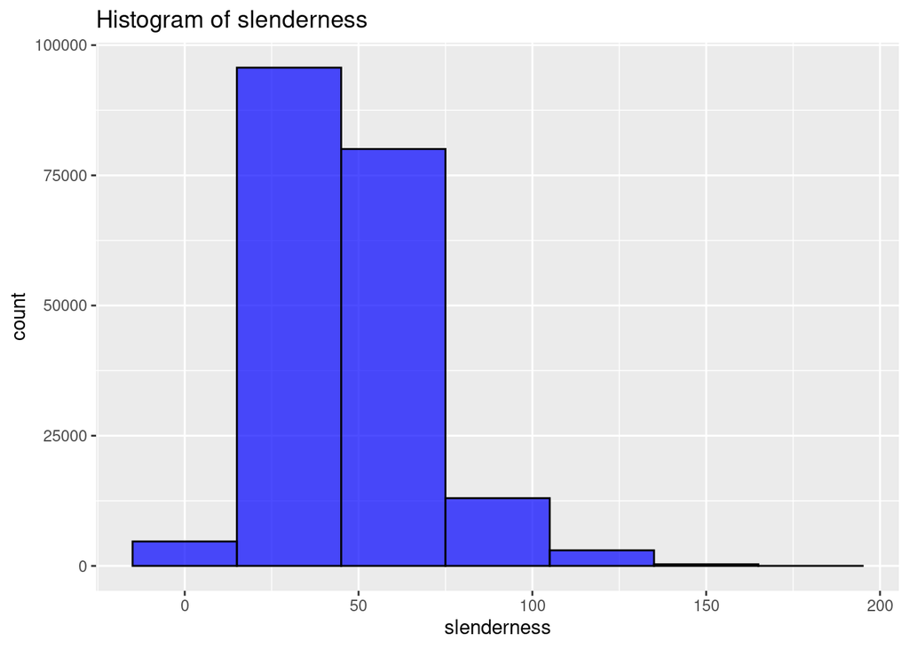

### Column: dominant_slenderness

Type: double

Number of missing values: 53980

```
##    Min. 1st Qu.  Median    Mean 3rd Qu.    Max.    NA's
##    0.13   31.72   40.03   42.26   50.01  178.34   53980
```

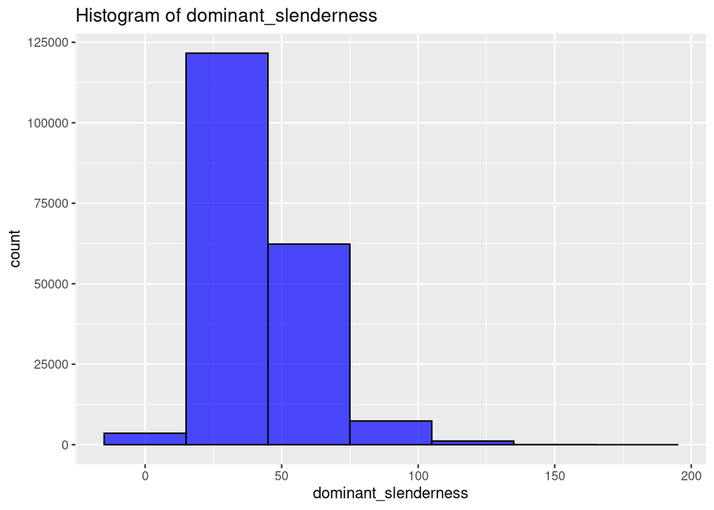

### Column: SDI

Type: double

Number of missing values: 53300

```
##     Min.  1st Qu.   Median     Mean  3rd Qu.     Max.     NA's
##     0.09   133.35   554.21  1194.94  1521.98 26329.07    53300
```

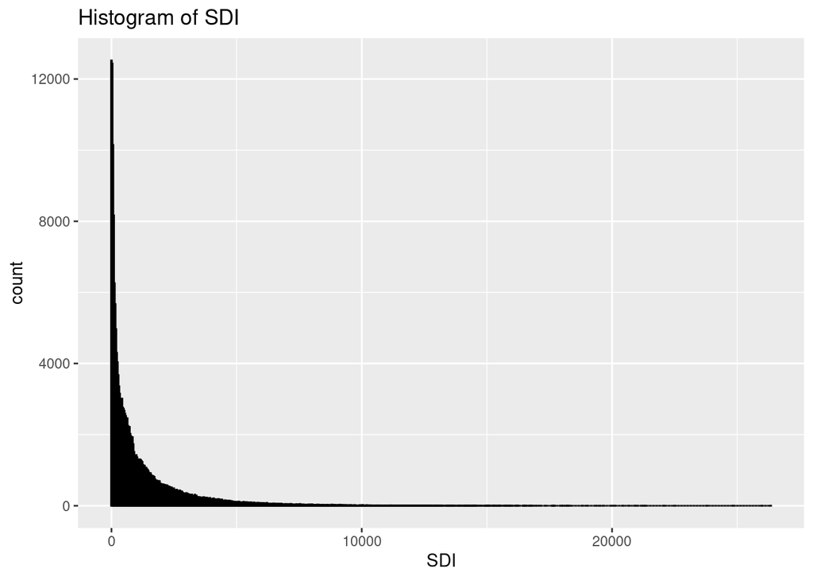

### Column: S

Type: double

Number of missing values: 53980

```
##     Min.  1st Qu.   Median     Mean  3rd Qu.     Max.     NA's
##     4.72    27.54    50.71    90.82   113.94 44311.35    53980
```

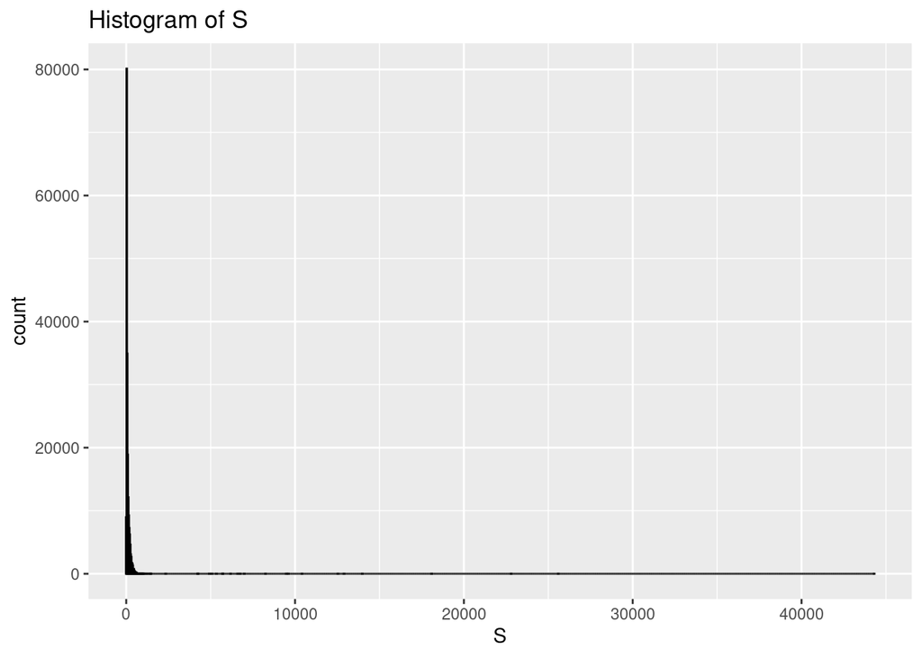

### Column: S_staggered

Type: double

Number of missing values: 53980

```
##     Min.  1st Qu.   Median     Mean  3rd Qu.     Max.     NA's
##     8.79    51.26    94.39   169.03   212.06 82472.71    53980
```

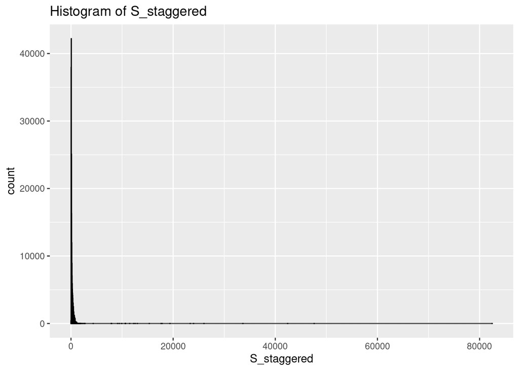

### Column: X_UTM

Type: double

Number of missing values: 14998

```
##    Min. 1st Qu.  Median    Mean 3rd Qu.    Max.    NA's
##   32000  380893  510000  500868  615037  776473   14998
```

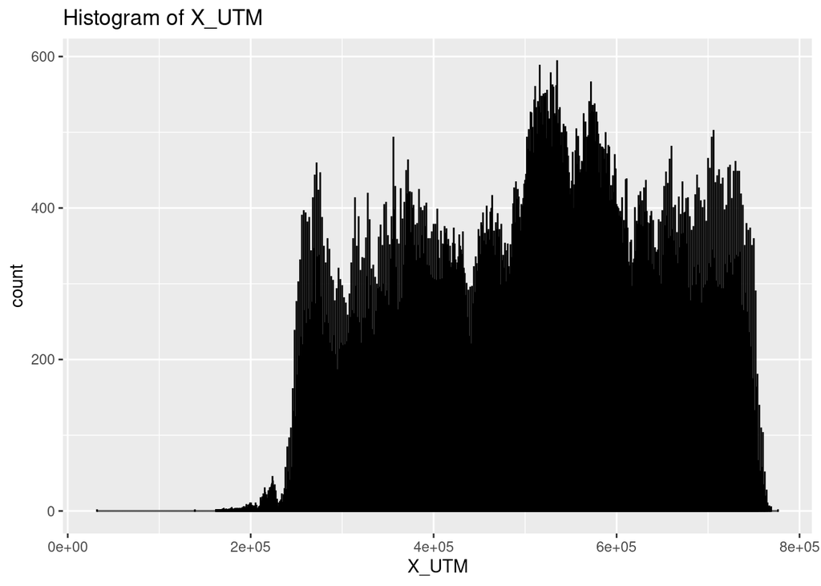

### Column: Y_UTM

Type: double

Number of missing values: 14155

```
##    Min. 1st Qu.  Median    Mean 3rd Qu.    Max.    NA's
## 2365000 4366000 4569000 4493672 4697000 4848000   14155
```

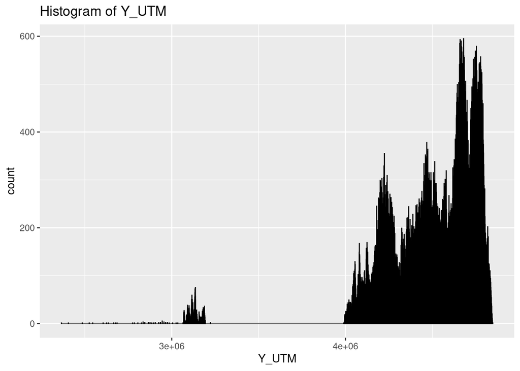

### Column: Longitude

Type: double

Number of missing values: 15148

```
##    Min. 1st Qu.  Median    Mean 3rd Qu.    Max.    NA's
## -18.139  -5.765  -3.212  -3.550  -1.309   4.297   15148
```

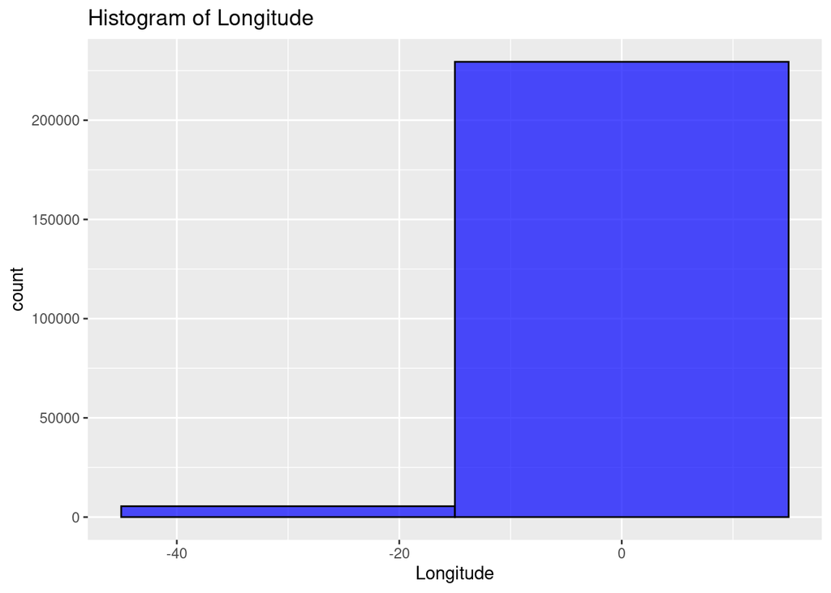

### Column: Latitude

Type: double

Number of missing values: 15148

```
##    Min. 1st Qu.  Median    Mean 3rd Qu.    Max.    NA's
##   27.67   39.46   41.27   40.63   42.42   43.78   15148
```

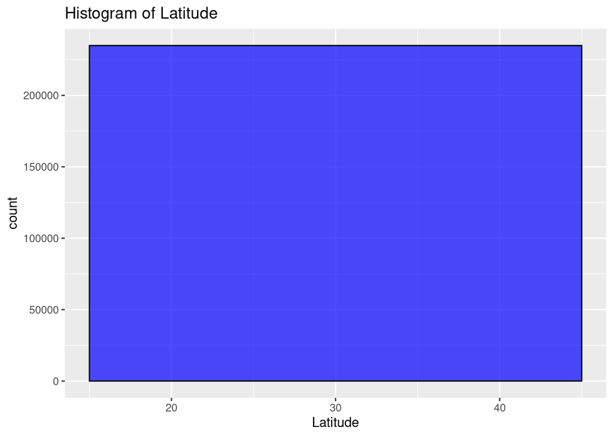

### Column: zone

Type: double

Number of missing values: 9634

```
##    Min. 1st Qu.  Median    Mean 3rd Qu.    Max.    NA's
##    28.0    30.0    30.0    29.9    30.0    31.0    9634
```

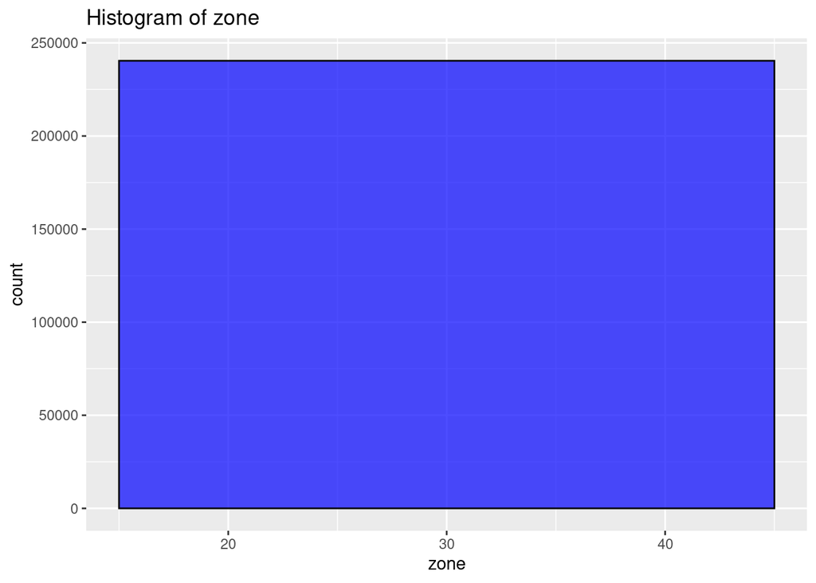